# Badawi Amin Muhammed

### Data Scientist • AI & ML Engineer • Research Data Analyst

# Foreasting Time Series Data in R with tidy

Badawi Amin Muhammed

2025-11-22

# Introduction

For almost a decade, the `forecast` package has been a rock-solid framework for time series forecasting. However, within the last year or so an official updated version has been released named `fable` which now follows `tidy` methods as opposed to base R.

More recently, `modeltime` has been released and this also follows tidy methods. However, it is strictly used for modeling. For data manipulation and visualization, the `timetk` package will be used which is written by the same author as `modeltime`.

The following is a code comparison of various time series visualizations between these frameworks: `fpp2`, `fpp3` and `timetk`.

#Load Libraries

```r
# Load libraries
library(fpp2)         # An older forecasting framework
library(fpp3)         # A newer tidy forecasting framework
library(timetk)       # An even newer tidy forecasting framework
library(tidyverse)    # Collection of data manipulation tools
library(tidyquant)    # Business Science ggplot theme
library(cowplot)      # A ggplot add-on for arranging plots
```

# TS vs tsibble

- the base *ts* object is used by `forecast` & `fpp2`
- The special *tsibble* object is used by `fable` & `fpp3`
- The standard tibble object is used by `timetk` & `modeltime`

# 1. Load Time Series Data

we will utilize a dataset containing quarterly production values of certain commodities in Australia.

```r
# Quarterly Australian production data as tibble
aus <- tsibbledata::aus_production %>% as_tibble()
# Check structure
aus %>% str()
```

```
## tibble [218 × 7] (S3: tbl_df/tbl/data.frame)
##  $ Quarter    : qtr [1:218] 1956 Q1, 1956 Q2, 1956 Q3, 1956 Q4, 1957 Q1, 1957 Q2, 1957...
##  $ Beer       : num [1:218] 284 213 227 308 262 228 236 320 272 233 ...
##  $ Tobacco    : num [1:218] 5225 5178 5297 5681 5577 ...
##  $ Bricks     : num [1:218] 189 204 208 197 187 214 227 222 199 229 ...
##  $ Cement     : num [1:218] 465 532 561 570 529 604 603 582 554 620 ...
##  $ Electricity: num [1:218] 3923 4436 4806 4418 4339 ...
##  $ Gas        : num [1:218] 5 6 7 6 5 7 7 6 5 7 ...
```

# 2 fpp2 Method: From tibble to ts

```r
# Convert tibble to time series object
aus_prod_ts <- ts(aus[, 2:7],  # Choose columns
                    start = c(1956, 1),  # Choose start date
                    end = c(2010, 2),    # Choose end date
                    frequency = 4)       # Choose frequency per yr
# Check it out
aus_prod_ts %>% tail()
```

```
##         Beer Tobacco Bricks Cement Electricity Gas
## 2009 Q1  415      NA     NA   1963       58368 196
## 2009 Q2  398      NA     NA   2160       57471 238
## 2009 Q3  419      NA     NA   2325       58394 252
## 2009 Q4  488      NA     NA   2273       57336 210
## 2010 Q1  414      NA     NA   1904       58309 205
## 2010 Q2  374      NA     NA   2401       58041 236
```

#3 fpp3 Method: From ts to tsibble

## 3.1 Pivot Wide

```r
# Convert ts to tsibble and keep wide format
aus_prod_tbl_wide <- aus_prod_ts %>%    # TS object
  as_tsibble(index = "index",           # Set index column
             pivot_longer = FALSE)      # Wide format
```

## 3.2 Pivot Long Convert ts to tsibble and pivot to long format

```r
aus_prod_tbl_long <- aus_prod_ts %>%    # TS object
  as_tsibble(index = "index", pivot_longer = TRUE) # Long format
```

#4 timetk Method: From tsibble/ts to tibble ## 4.1 Pivot Wide

```r
# Convert tsibble to tibble, keep wide format
aus <- tsibbledata::aus_production %>%
    tk_tbl() %>%
    mutate(Quarter = as_date(as.POSIXct.Date(Quarter)))
```

## 4.2 Pivot Long

```r
# Quarterly Australian production data to long format
aus_long <- aus %>%
    rename(date = Quarter) %>%
    pivot_longer(
        cols = c("Beer","Tobacco","Bricks",
                 "Cement","Electricity","Gas"))
```

# 5. Time Series Plots

When analyzing time series plots, look for the following patterns:

-**Trend**: A long-term increase or decrease in the data; a “changing direction”.

_**Seasonality**: A seasonal pattern of a fixed and known period. If the frequency is unchanging and associated with some aspect of the calendar, then the pattern is seasonal.

-**Cycle**: A rise and fall pattern not of a fixed frequency. If the fluctuations are not of a fixed frequency then they are cyclic.

-**Seasonal vs Cyclic**: Cyclic patterns are longer and more variable than seasonal patterns in general.

# 5.1 fpp2 Method: Plot Multiple Series On Same Axes

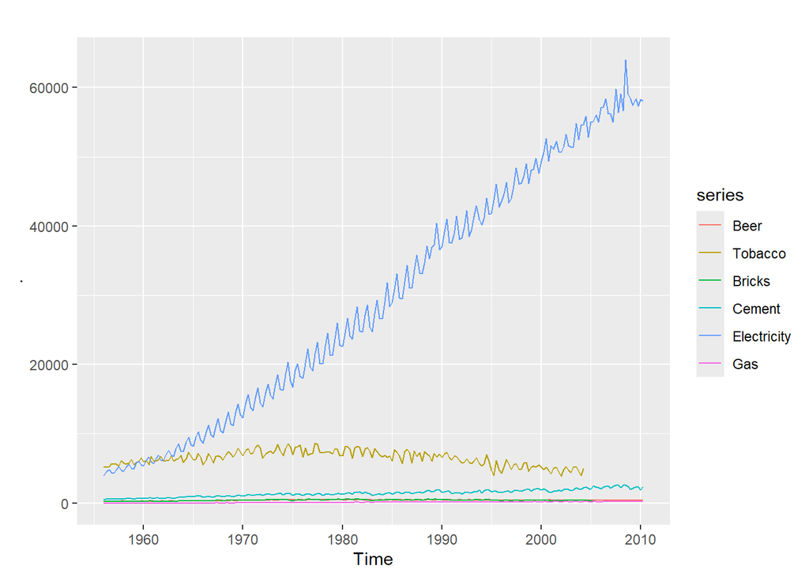

quaterly production of selected quantities using fpp2

```r
# Using fpp2
aus_prod_ts %>%               # TS object
  autoplot(facets=FALSE)      # No facetting
```

## 5.2 fpp3 Method: Plot Multiple Series On Same Axes

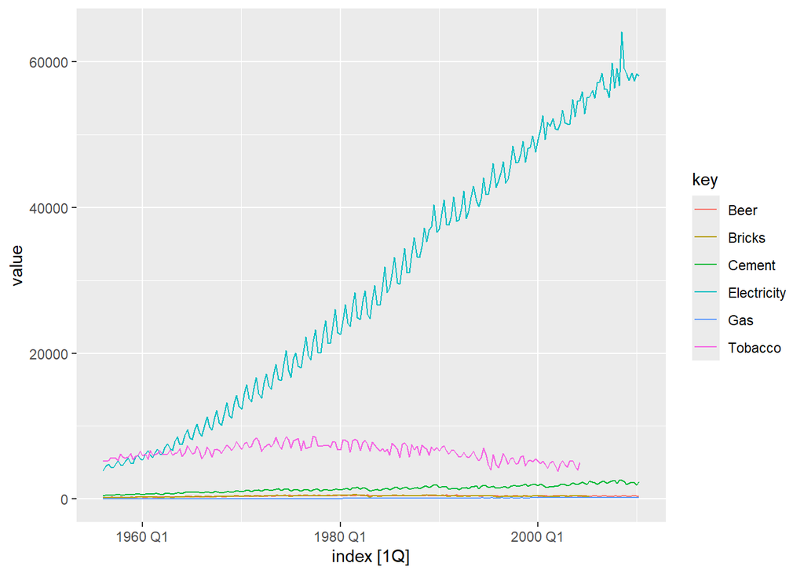

quaterly production of selected quantities using fpp3

```r
# Using fpp3
aus_prod_tbl_long %>%    # Data in long format
  autoplot(value)
```

## 5.3 ggplot Method: Plot Multiple Series On Same Axes

plotting multiple plots on the same axes has not been implemented into `timetk`. hence, we Use `ggplot`.

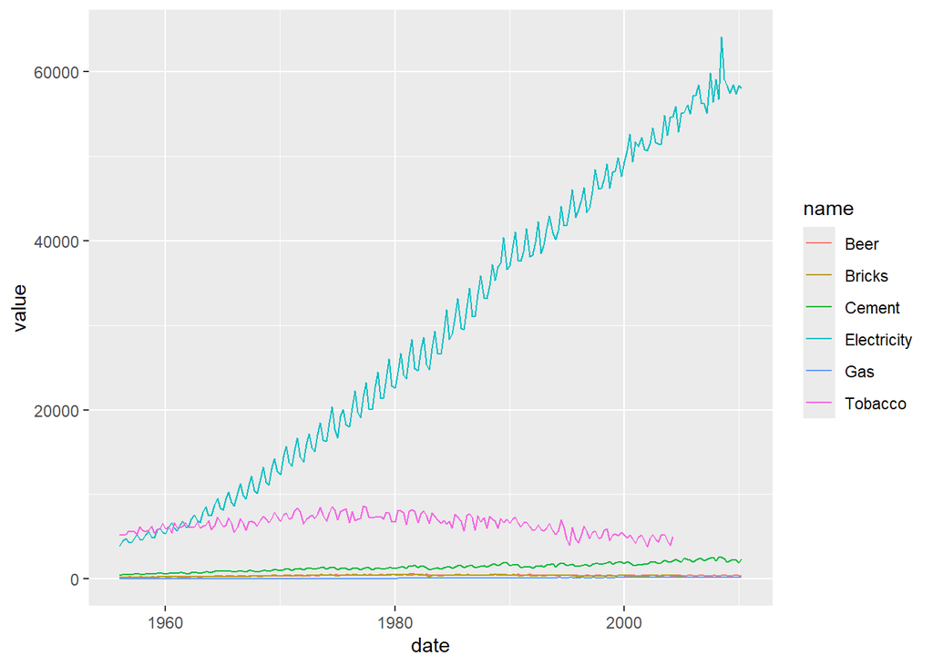

quaterly production of selected quantities using ggplot

```r
# Using ggplot
aus_long %>%
    ggplot(aes(date, value, group = name, color = name)) +
    geom_line()
```

## 5.4 fpp2 Method: Plot Multiple Series On Separate Axes

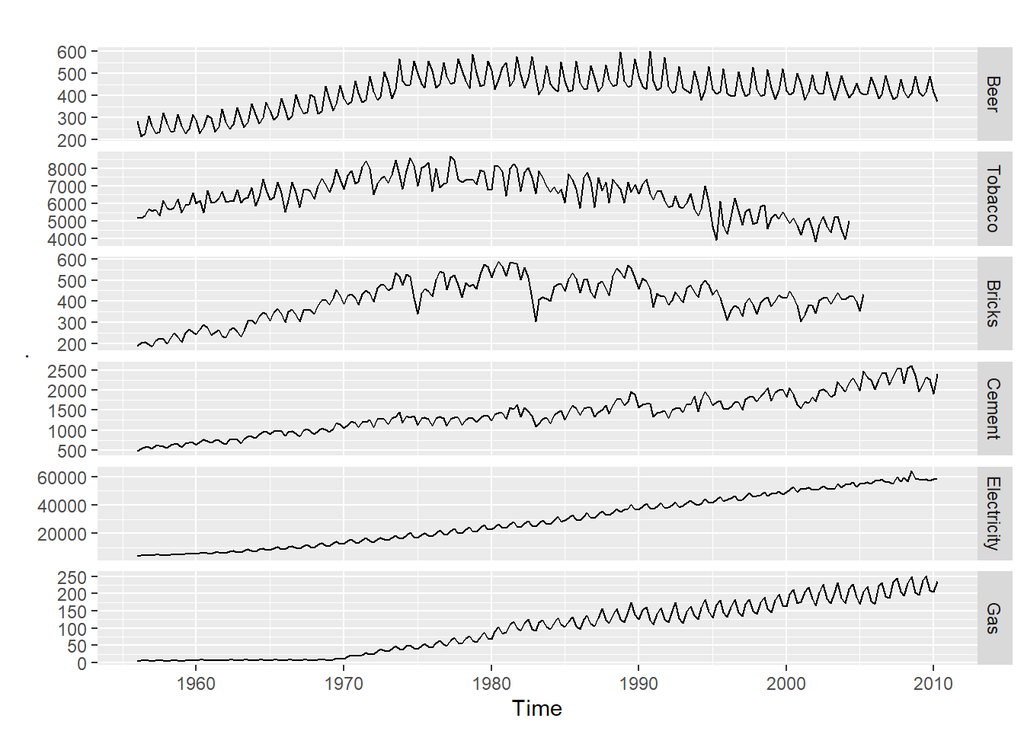

quaterly production of selected quantities using fpp2

```r
# Using fpp2
aus_prod_ts %>%
  autoplot(facets=TRUE)   # With facetting
```

## 5.5 fpp3 Method: Plot Multiple Series On Separate Axes

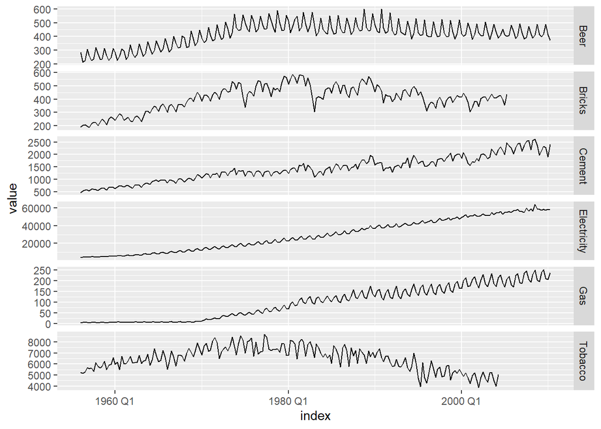

quaterly production of selected quantities using fpp3

```r
# Using fpp3
aus_prod_tbl_long %>%
  ggplot(aes(x = index, y = value, group = key)) +
  geom_line() +
  facet_grid(vars(key), scales = "free_y")   # With facetting
```

## 5.6 timetk Method: Plot Multiple Series On Separate Axes

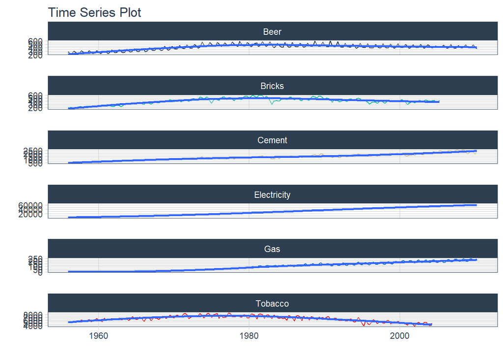

quaterly production of selected quantities using timetk

```r
# Using timetk
aus_long %>%
    plot_time_series(
        .date_var = date,
        .value = value,
        .facet_vars = c(name), # Group by these columns
        .color_var = name,
        .interactive = FALSE,
        .legend_show = FALSE
    )
```

# Seasonal Plots

Use seasonal plots for identifying time periods in which the patterns change.

## 6.1 fpp2 Method: Plot Individual Seasons

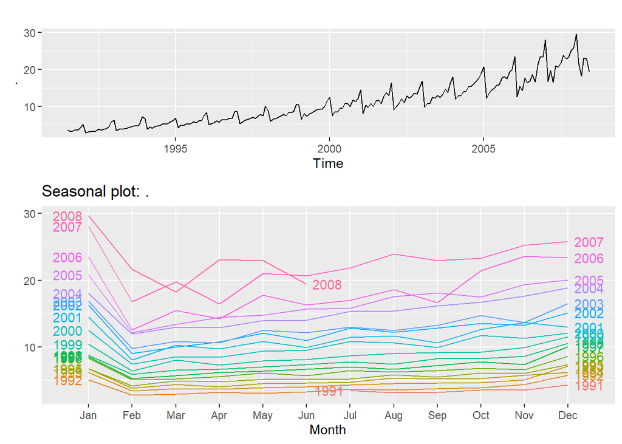

Monthly plot of anti-diabetic scripts

```r
# Monthly plot of anti-diabetic scripts in Australia
a1 <- a10 %>%
  autoplot()
# Seasonal plot
a2 <- a10 %>%
  ggseasonplot(year.labels.left = TRUE,   # Add labels
               year.labels = TRUE)
# Arrangement of plots
plot_grid(a1, a2, ncol=1, rel_heights = c(1, 1.5))
```

# 6.2 fpp3 Method: Plot Individual Seasons

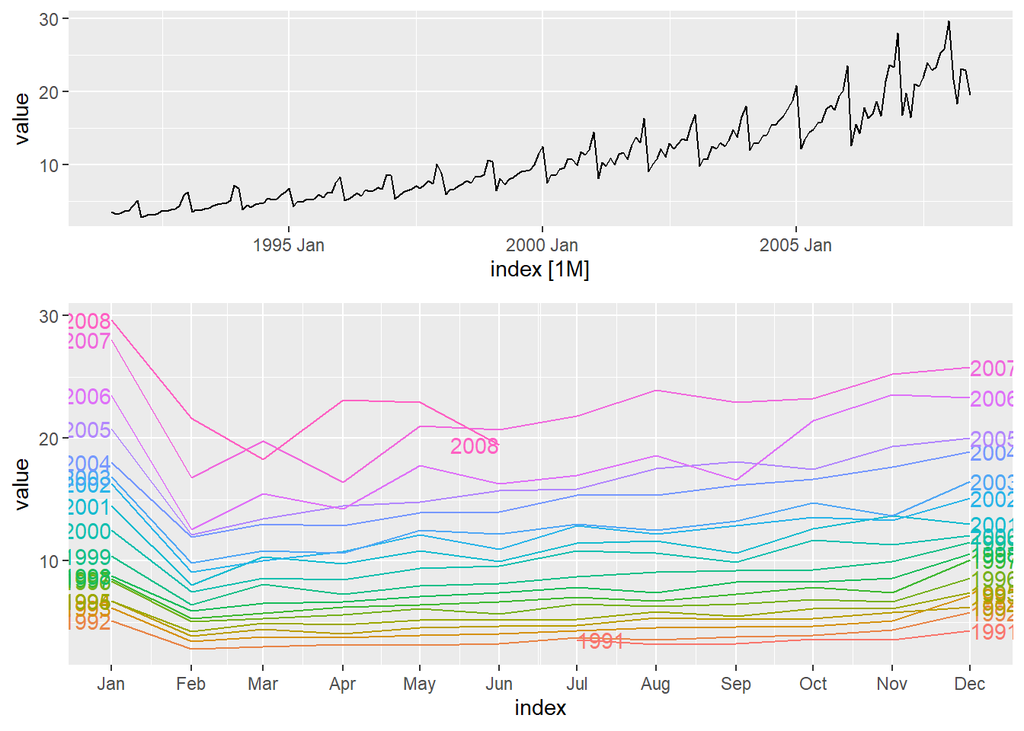

Monthly plot of anti-diabetic scripts

```r
# Monthly plot of anti-diabetic scripts in Australia
a1 <- a10 %>%
  as_tsibble() %>%
  autoplot(value)
# Seasonal plot
a2 <- a10 %>%
  as_tsibble() %>%
  gg_season(value, labels="both")   # Add labels
# Arrangement of plots
plot_grid(a1, a2, ncol=1, rel_heights = c(1, 1.5))
```

## 6.3 ggplot Method: Plot Individual Seasons

Note that seasonal plots have not been implemented into `timetk` .hence, Use `ggplot` to write:

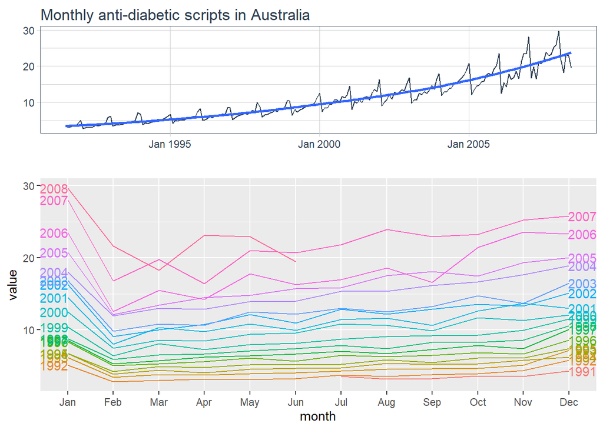

Monthly plot of anti-diabetic scripts

```r
# Convert ts to tibble
a10_tbl <- fpp2::a10 %>%
    tk_tbl()
# Monthly plot of anti-diabetic scripts in Australia
a1 <- a10_tbl %>%
    plot_time_series(
        .date_var = index,
        .value    = value,
        .smooth   = TRUE,
        .interactive = FALSE,
        .title = "Monthly anti-diabetic scripts in Australia"
    )
# New time-based features to group by
a10_tbl_add <- a10_tbl %>%
    mutate(
        month = factor(month(index, label = TRUE)),  # Plot this
        year = factor(year(index))  # Grouped on y-axis
    )
# Seasonal plot
a2 <- a10_tbl_add %>%
    ggplot(aes(x = month, y = value,
               group = year, color = year)) +
    geom_line() +
    geom_text(
        data = a10_tbl_add %>% filter(month == min(month)),
        aes(label = year, x = month, y = value),
        nudge_x = -0.3) +
    geom_text(
        data = a10_tbl_add %>% filter(month == max(month)),
        aes(label = year, x = month, y = value),
        nudge_x = 0.3) +
    guides(color = FALSE)
# Arrangement of plots
plot_grid(a1, a2, ncol=1, rel_heights = c(1, 1.5))
```

# 7. Lag Plots

Use lag plots to check for randomness.

## 7.1 fpp2 Method: Plot Multiple Lags

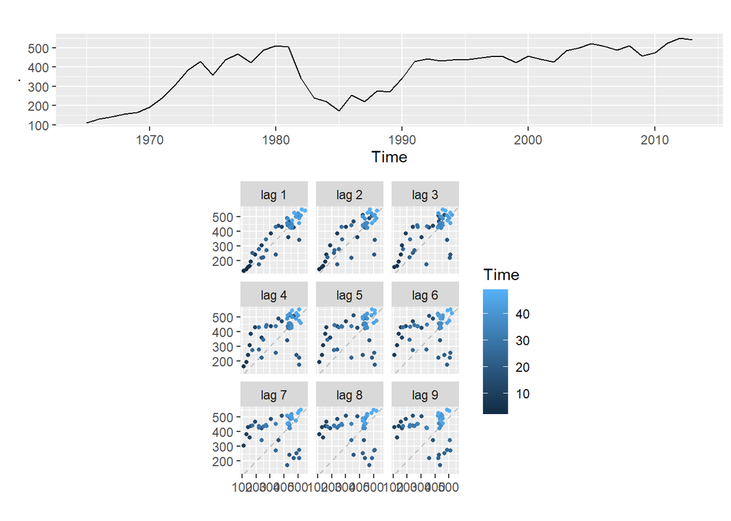

Annual oil production in Saudi Arabia

```r
# Plot of non-seasonal oil production in Saudi Arabia
o1 <- fpp2::oil %>%
  autoplot()
# Lag plot of non-seasonal oil production
o2 <- gglagplot(oil, do.lines = FALSE)
# Plot both
plot_grid(o1, o2, ncol=1, rel_heights = c(1,2))
```

## 7.2 fpp3 Method: Plot Multiple Lags

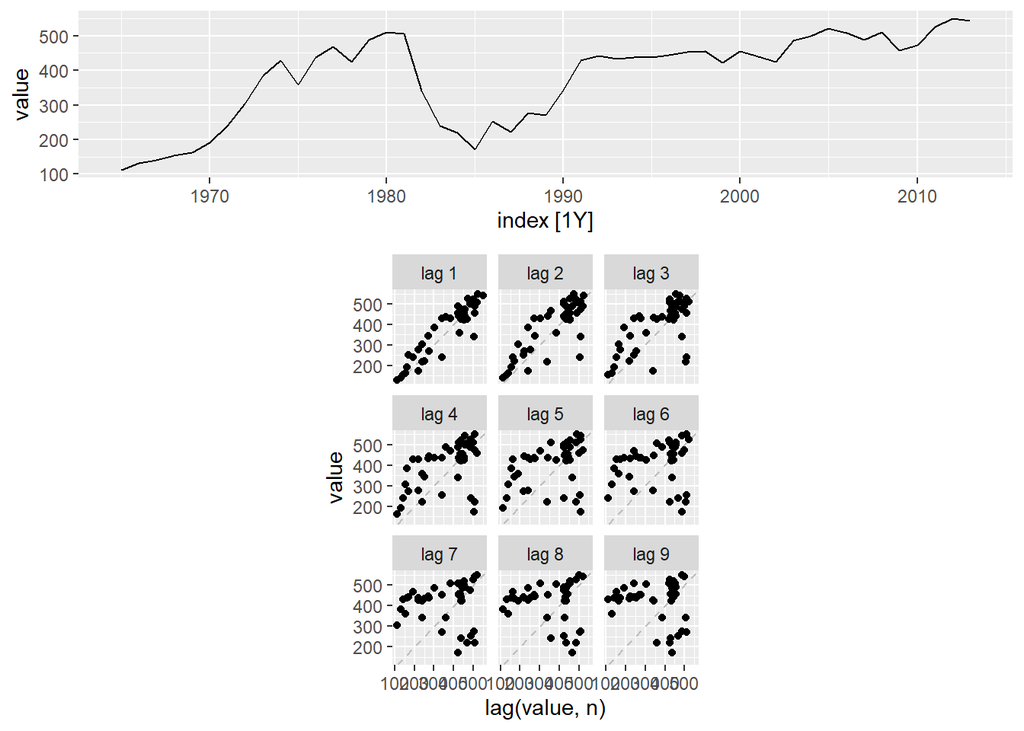

Annual oil production in Saudi Arabia

```r
# Plot of non-seasonal oil production
o1 <- oil %>%
  as_tsibble() %>%
  autoplot(value)
# Lag plot of non-seasonal oil production
o2 <- oil %>%
  as_tsibble() %>%
  gg_lag(y=value, geom = "point")
# Plot it
plot_grid(o1, o2, ncol=1, rel_heights = c(1,2))
```

## 7.3 timetk Method: Plot Multiple Lags

```r
# Convert to tibble and create lag columns
oil_lag_long <- oil %>%
    tk_tbl(rename_index = "year") %>%
    tk_augment_lags(      # Add 9 lag columns of data
        .value = value,
        .names = "auto",
        .lags = 1:9) %>%
    pivot_longer(         # Pivot from wide to long
        names_to = "lag_id",
        values_to = "lag_value",
        cols = value_lag1:value_lag9) # Exclude year & value
```

then the plot:

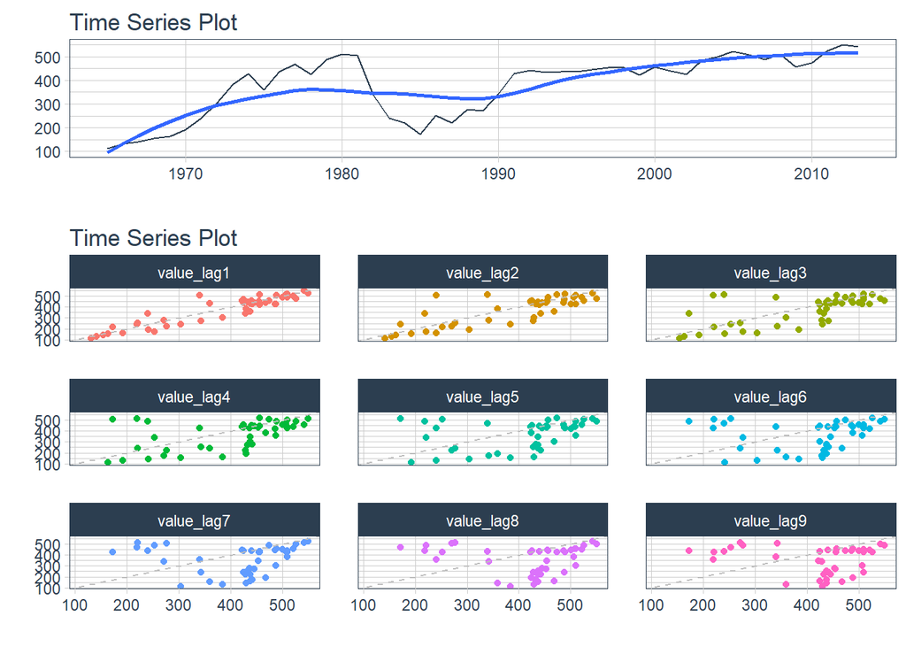

Annual oil production in Saudi Arabia

```r
# Time series plot
o1 <- oil %>%
    tk_tbl(rename_index = "year") %>%
    mutate(year = ymd(year, truncated = 2L)) %>%
    plot_time_series(
        .date_var = year,
        .value = value,
        .interactive = FALSE)
# timetk Method: Plot Multiple Lags
o2 <- oil_lag_long %>%
    plot_time_series(
        .date_var = value,     # Use value instead of date
        .value = lag_value,    # Use lag value to plot against
        .facet_vars = lag_id,  # Facet by lag number
        .facet_ncol = 3,
        .interactive = FALSE,
        .smooth = FALSE,
        .line_alpha = 0,
        .legend_show = FALSE,
        .facet_scales = "fixed"
        ) +
    geom_point(aes(colour = lag_id)) +
    geom_abline(colour = "gray", linetype = "dashed")
# Plot it
plot_grid(o1, o2, ncol=1, rel_heights = c(1,2))
```

# 8. Autocorrelation Function Plots

The autocorrelation function measures the linear relationship between lagged values of a time series. The partial autocorrelation function measures the linear relationship between the correlations of the residuals.

**ACF**

-Visualizes how much the most recent value of the series is correlated with past values of the series (lags) -If the data has a trend, then the autocorrelations for small lags tend to be positive and large because observations nearby in time are also nearby in size -If the data are seasonal, then the autocorrelations will be larger for seasonal lags at multiples of seasonal frequency than other lags

**PACF**

-Visualizes whether certain lags are good for modeling or not; useful for data with a seasonal pattern Removes dependence of lags on other lags by using the correlations of the residuals

## 8.1 fpp2 Method: Plot ACF + PACF

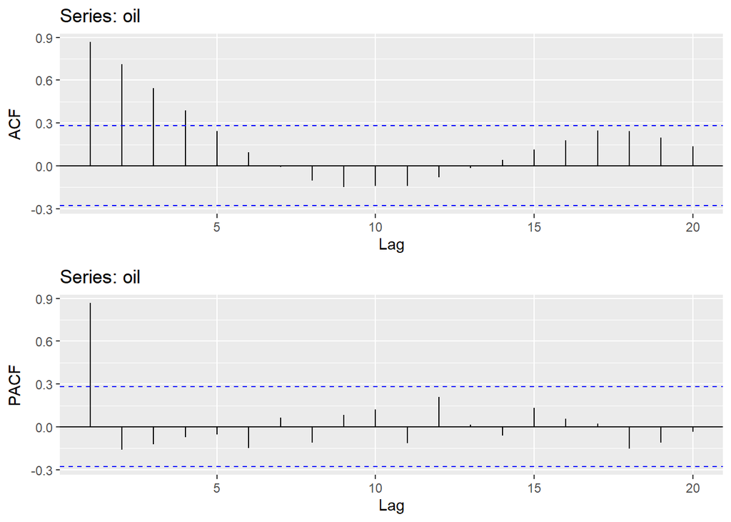

Auto Correlation Function

```r
# ACF plot
o1 <- ggAcf(oil, lag.max = 20)
# PACF plot
o2 <- ggPacf(oil, lag.max = 20)
# Plot both
plot_grid(o1, o2, ncol = 1)
```

## 8.2 fpp3 Method: Plot ACF + PACF

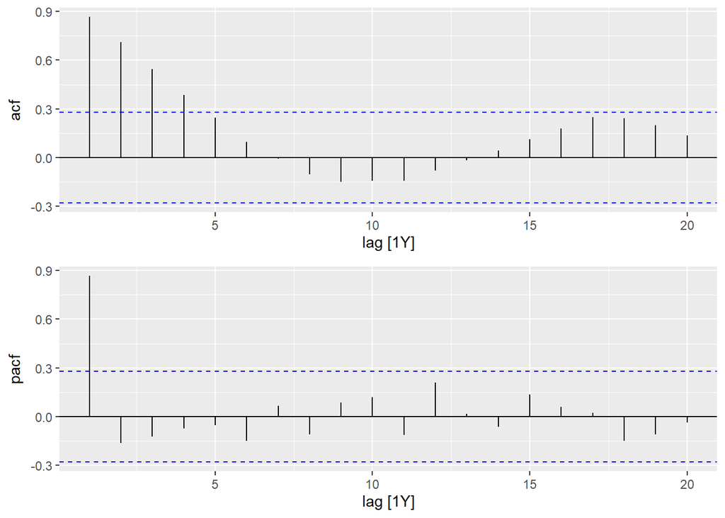

Auto Correlation Function

```r
# Convert to tsibble
oil_tsbl <- oil %>% as_tsibble()
# ACF Plot
o1 <- oil_tsbl %>%
  ACF(lag_max = 20) %>%
  autoplot()
# PACF Plot
o2 <- oil_tsbl %>%
  PACF(lag_max = 20) %>%
  autoplot()
# Plot both
plot_grid(o1, o2, ncol = 1)
```

## 7.3 timetk Method: Plot ACF & PACF

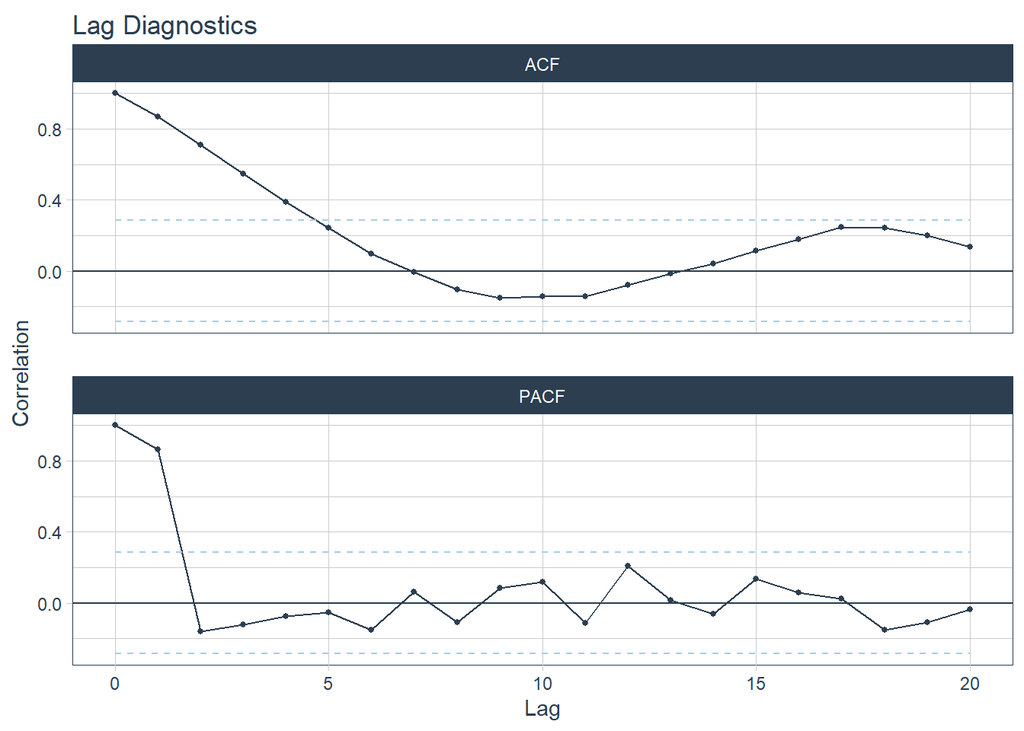

Auto Correlation Function

```r
# Using timetk
oil %>%
    tk_tbl(rename_index = "year") %>%
    plot_acf_diagnostics(
        .date_var = year,
        .value    = value,
        .lags     = 20,
        .show_white_noise_bars = TRUE,
        .interactive = FALSE
    )
```

# Summary

As with all things in life, there are good and bad sides to using any of these three forecasting frameworks for visualizing time series. All three have similar functionality as it relates to visualizations.

**fpp2**

-Code requires minimal parameters -Uses basets format -Uses `ggplot` for visualizations -Mostly incompatible with tidyverse for data manipulation -No longer maintained except for bug fixes

**fpp3**

-Code requires minimal parameters -Uses proprietary tsibble format with special indexing tools -Uses `ggplot` for visualizations -Mostly compatible with tidyverse for data manipulation; tsibble may cause issues -Currently maintained

**timetk**

-Code requires multiple parameters but provides more granularity -Uses standard tibble format -Uses `ggplot` and `plotly` for visualizations -Fully compatible with `tidyverse` for data manipulation -Currently maintained